# SALES FORECASTING FOR SMALL BASKET

## Business case

Small basket is a huge online/mobile based grocery retailer in India, founded in 2011. Small basket is trying to manage its supply chain and delivery partners and would like to accurately forecast the sales. Sales forecasting aides in the following:

- Allows to plan ahead and develop an effective sales plan. Prevent possible problems from occurring.
- Allocate budget. Knowing whether to spend or conserve with confidence in order to support dealerships. A sales forecast can help a company make sensible investments and avoid purchasing too much or too little stock.
- Assess sales performance – provides an idea of how your sales teams are performing both individually and as a whole.
- Set goals - With a firm indication of your expected sales, you can set your team goals that you are confident are achievable because they are based on statistical data. More attainable goals will create fair competition.

## Problem Statement

Small Basket is trying to manage its supply chain and delivery partners and would like to accurately forecast the sales for the period starting from 1st January 2019 to 15th January 2019 across several locations and product categories.

The data provided contains item details, daily item unit sales, location details and daily transactions made by each location. Using historical data, we can use these details to train a model that can predict the unit sales for each item for each location. This will help the business to plan ahead on future stock and dealerships.

## The Machine Learning Pipeline

- Problem Statement: Sales Forecasting for SmallBasket.
- Domain Understanding, deciding the performance metric: MAPE
- Data Extraction: Train data
- Data Understanding: Summary Statistics,aggregation, Missing values etc
- Data Preprocessing: Data type conversion, train validation split.
- Feature Engineering: Created features like day_of_week, isWeekend, month, year.
- Visualization: Top 10 items sold, distribution of locations in different cities, states, types and clusters. Total unit sales of different location etc.
- Model Building: using Random Forest, Decision Tree, XG Boost, Light Gradient Boosting Model and Neural Networks
- Performance tuning of the model and performance on unseen data: Used Cross validation and gridsearch for performance tuning.
- Summary,conclusion and recommendations to the business.

# Loading the required libraries

```python
import pandas as pd
import os
import numpy as np

# Supress Warnings

import warnings
warnings.filterwarnings('ignore')

import seaborn as sns
color = sns.color_palette()
import matplotlib.pyplot as plt
%matplotlib inline

import statsmodels.formula.api as smf
from sklearn.feature_selection import chi2
import pickle as pkl
import shutil
from sklearn.model_selection import train_test_split
from datetime import date, timedelta

from sklearn.metrics import mean_squared_error
from google.colab import drive
```

**Initial directory setting and reading file from google drive**

```python
os.getcwd()
```

```
'/content'
```

```python
os.listdir('/content/drive/My Drive/PhD datasets/')
```

```
['20120209_CSE9099c_PHD_Sales_Forecasting-1580995004969.pdf',
 'train_transactions.csv',
 'item_details.csv',
 'location_details.csv',
 'train.csv',
 'sample_submission.csv',
 'test.csv',
 'data_test',
 'data_dt',
 'preds.csv',
 'predictions2.csv',
 'lgbm.txt',
 'predictsDT.csv',
 'data_x_train',
 'data_y_train',
 'data_y_valid',
 'data_x_valid']
```

```python
os.chdir('/content/drive/My Drive/PhD datasets/')
```

```python
data = pd.read_csv('train.csv')
```

```python
#Drop duplicates from train
print("Before dropping" , data.shape)
data.drop_duplicates(inplace=True)
print('after dropping' , data.shape)
```

```
Before dropping (101688779, 5)
after dropping (101678735, 5)
```

```python
#Read other given files
data_loc = pd.read_csv('location_details.csv')
data_trans = pd.read_csv('train_transactions.csv')
data_items = pd.read_csv('item_details.csv')
```

# DATA INSPECTION

**Identifying Unique values in each Column**

```python
for i in data.columns.values:
    print (i)
    print (len(data[i].unique()))
```

```
date
1456
locationId
53
item_id
3890
unit_sales
244090
onpromotion
3
```

```python
data.head(10)
```

|  | date | locationId | item_id | unit_sales | onpromotion |
| --- | --- | --- | --- | --- | --- |
| 0 | 2015-01-01 | location_25 | item_103665 | 7.0 | NaN |
| 1 | 2015-01-01 | location_25 | item_105574 | 1.0 | NaN |
| 2 | 2015-01-01 | location_25 | item_105575 | 2.0 | NaN |
| 3 | 2015-01-01 | location_25 | item_108079 | 1.0 | NaN |
| 4 | 2015-01-01 | location_25 | item_108701 | 1.0 | NaN |
| 5 | 2015-01-01 | location_25 | item_108786 | 3.0 | NaN |
| 6 | 2015-01-01 | location_25 | item_108797 | 1.0 | NaN |
| 7 | 2015-01-01 | location_25 | item_108952 | 1.0 | NaN |
| 8 | 2015-01-01 | location_25 | item_111397 | 13.0 | NaN |
| 9 | 2015-01-01 | location_25 | item_114790 | 3.0 | NaN |

```python
data.describe(include='all')
```

|  | date | locationId | item_id | unit_sales | onpromotion |
| --- | --- | --- | --- | --- | --- |
| count | 101678735 | 101678735 | 101678735 | 1.016787e+08 | 80021084 |
| unique | 1456 | 53 | 3890 | NaN | 2 |
| top | 2018-02-28 | location_44 | item_314384 | NaN | False |
| freq | 183386 | 2877985 | 71406 | NaN | 74960323 |
| mean | NaN | NaN | NaN | 8.648406e+00 | NaN |
| std | NaN | NaN | NaN | 2.349639e+01 | NaN |
| min | NaN | NaN | NaN | -1.537200e+04 | NaN |
| 25% | NaN | NaN | NaN | 2.000000e+00 | NaN |
| 50% | NaN | NaN | NaN | 4.000000e+00 | NaN |
| 75% | NaN | NaN | NaN | 9.000000e+00 | NaN |
| max | NaN | NaN | NaN | 8.944000e+04 | NaN |

```python
## Checking for missing values
data.isna().sum()
```

```
date                  0
locationId            0
item_id               0
unit_sales            0
onpromotion    21657651
dtype: int64
```

```python
data_loc.head(10)
```

|  | location_id | city | state | type | cluster |
| --- | --- | --- | --- | --- | --- |
| 0 | location_1 | Bengaluru | Karnataka | D | 13 |
| 1 | location_2 | Bengaluru | Karnataka | D | 13 |
| 2 | location_3 | Bengaluru | Karnataka | D | 8 |
| 3 | location_4 | Bengaluru | Karnataka | D | 9 |
| 4 | location_5 | Delhi | NCR | D | 4 |
| 5 | location_6 | Bengaluru | Karnataka | D | 13 |
| 6 | location_7 | Bengaluru | Karnataka | D | 8 |
| 7 | location_8 | Bengaluru | Karnataka | D | 8 |
| 8 | location_9 | Bengaluru | Karnataka | B | 6 |
| 9 | location_10 | Bengaluru | Karnataka | C | 15 |

```python
data_loc['type'].value_counts()
```

```
D    18
C    15
A     9
B     8
E     4
Name: type, dtype: int64
```

```python
data_loc['cluster'].value_counts()
```

```
3     7
6     6
10    6
15    5
14    4
13    4
1     3
11    3
8     3
4     3
2     2
9     2
7     2
5     1
16    1
12    1
17    1
Name: cluster, dtype: int64
```

```python
data.shape
```

```
(101678735, 5)
```

```python
data.dtypes
```

```
date            object
locationId      object
item_id         object
unit_sales     float64
onpromotion     object
dtype: object
```

```python
data['onpromotion'].value_counts()
```

```
False    74960323
True      5060761
Name: onpromotion, dtype: int64
```

```
Index([False, True], dtype='object') [74960323  5060761]
```

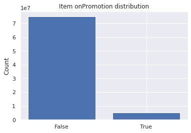

```python
values = data['onpromotion'].value_counts()#.sort_values().plot(kind = 'bar')
print(values.keys(),values.values)
ypos = np.arange(len(values.keys()))
#print(ypos)
plt.bar(ypos,values.values)
plt.ylabel('Count')
plt.xticks(ypos,values.keys() )
plt.title('Item onPromotion distribution')
plt.show()
```

```python
print(data['unit_sales'].isna().sum())
```

```
0
```

```python
data_trans.head()
```

|  | date | location_identifier | transactions |
| --- | --- | --- | --- |
| 0 | 2015-01-01 | location_25 | 770 |
| 1 | 2015-01-02 | location_1 | 2111 |
| 2 | 2015-01-02 | location_2 | 2358 |
| 3 | 2015-01-02 | location_3 | 3487 |
| 4 | 2015-01-02 | location_4 | 1922 |

```python
print(data['onpromotion'].unique())
```

```
[nan False True]
```

Exploratory Data Analysis

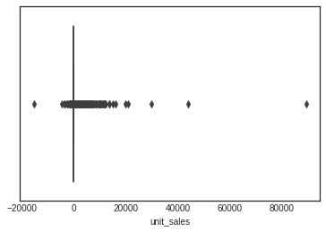

```python
plt.style.use('seaborn-white')
sns.boxplot(data['unit_sales'])
plt.show()
```

```python
#Check the distribution of items sold top 10 and bottom 10
values = data['item_id'].value_counts()
print(values[:10])
print(values[-10:])
```

```
item_314384     71406
item_502331     71396
item_364606     71261
item_265559     71051
item_559870     70702
item_564533     70567
item_273528     70226
item_1036689    70214
item_414353     69925
item_839363     69888
Name: item_id, dtype: int64
item_2003392    11
item_2075733    10
item_2043198    10
item_2108843     9
item_2091318     8
item_2058907     8
item_2028403     6
item_2056549     5
item_2042314     4
item_1047793     3
Name: item_id, dtype: int64
```

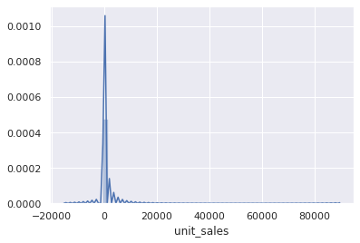

```python
#Checking the distribution of target variable
sns.set()
ax = sns.distplot(data.unit_sales)
```

**Until here the required data is ready which needs to be further preprocessed before applying visualization and building the model**

# DATA PREPROCESSING

**1). Looking at data types of variables and changing them if necessary**

```python
data.dtypes
```

```
date            object
locationId      object
item_id         object
unit_sales     float64
onpromotion     object
dtype: object
```

```python
data.describe(include='all')
```

|  | date | locationId | item_id | unit_sales | onpromotion |
| --- | --- | --- | --- | --- | --- |
| count | 101678735 | 101678735 | 101678735 | 1.016787e+08 | 80021084 |
| unique | 1456 | 53 | 3890 | NaN | 2 |
| top | 2018-02-28 | location_44 | item_314384 | NaN | False |
| freq | 183386 | 2877985 | 71406 | NaN | 74960323 |
| mean | NaN | NaN | NaN | 8.648406e+00 | NaN |
| std | NaN | NaN | NaN | 2.349639e+01 | NaN |
| min | NaN | NaN | NaN | -1.537200e+04 | NaN |
| 25% | NaN | NaN | NaN | 2.000000e+00 | NaN |
| 50% | NaN | NaN | NaN | 4.000000e+00 | NaN |
| 75% | NaN | NaN | NaN | 9.000000e+00 | NaN |
| max | NaN | NaN | NaN | 8.944000e+04 | NaN |

```python
#Converting date to datetime
data.date = data.date.astype('datetime64[ns]')
```

**Extraction Of Information fro Date column**

```python
#Extracting new time feature
data['week'] = data['date'].dt.week
data['month'] = data['date'].dt.month
data['year']= data['date'].dt.year
data['day'] = data['date'].dt.day
data['day_of_week'] = data['date'].dt.dayofweek
```

```python
data['day'].value_counts()
```

```
2     3455158
3     3429751
28    3402810
4     3401509
5     3386539
6     3376720
16    3374983
20    3370523
23    3361087
17    3350852
21    3347504
7     3343382
18    3341622
19    3340947
24    3340765
```

[output cut: 17 more lines]

```python
data["date"].dt.weekday_name.value_counts()
#More items were sold on tuesdays
```

```
Tuesday      15223305
Wednesday    14899359
Monday       14678415
Thursday     14352160
Friday       14217285
Saturday     14202226
Sunday       14105985
Name: date, dtype: int64
```

```python
#Check whether more items were sold on weekends or weekdays
data['isweekend'] = np.where(data['day_of_week'].isin([5,6]),1,0)
data[['date','isweekend']].tail()
```

|  | date | isweekend |
| --- | --- | --- |
| 101688774 | 2018-12-31 | 0 |
| 101688775 | 2018-12-31 | 0 |
| 101688776 | 2018-12-31 | 0 |
| 101688777 | 2018-12-31 | 0 |
| 101688778 | 2018-12-31 | 0 |

```python
data.isweekend.value_counts()
#As per the data, more reviews were written on the weekdays
```

```
0    73370524
1    28308211
Name: isweekend, dtype: int64
```

```python
data.head()
```

|  | date | locationId | item_id | unit_sales | onpromotion | week | month | year | day | day_of_week | isweekend |
| --- | --- | --- | --- | --- | --- | --- | --- | --- | --- | --- | --- |
| 0 | 2015-01-01 | location_25 | item_103665 | 7.0 | NaN | 1 | 1 | 2015 | 1 | 3 | 0 |
| 1 | 2015-01-01 | location_25 | item_105574 | 1.0 | NaN | 1 | 1 | 2015 | 1 | 3 | 0 |
| 2 | 2015-01-01 | location_25 | item_105575 | 2.0 | NaN | 1 | 1 | 2015 | 1 | 3 | 0 |
| 3 | 2015-01-01 | location_25 | item_108079 | 1.0 | NaN | 1 | 1 | 2015 | 1 | 3 | 0 |
| 4 | 2015-01-01 | location_25 | item_108701 | 1.0 | NaN | 1 | 1 | 2015 | 1 | 3 | 0 |

Data cleaning

```python
data.isna().sum()*100/data.shape[0]
```

```
date            0.000000
locationId      0.000000
item_id         0.000000
unit_sales      0.000000
onpromotion    21.300079
week            0.000000
month           0.000000
year            0.000000
day             0.000000
day_of_week     0.000000
isweekend       0.000000
dtype: float64
```

```python
#Handling na's in onpromotion
## Looking at data we assumme that na's in promotion means that there is no promotion included. As no promotion is significant it would be filling
## with the mode

data['onpromotion'].fillna(0,inplace =True)
```

```python
##Dealing with ordinal values and reducing the amount of memory required to store the variable through data type conversion
promotion_lev = data['onpromotion'].unique()
```

```python
promotion_level_mapping = {categorical_level: idx for
                             idx, categorical_level in
                             enumerate(promotion_lev, 0)}
```

```python
promotion_level_mapping
```

```
{0: 0, True: 1}
```

```python
data['onpromotion'] = data['onpromotion'].map(promotion_level_mapping)
```

```python
print(data['onpromotion'].unique())
```

```
[0 1]
```

```python
data.onpromotion.value_counts()
```

```
0    96617974
1     5060761
Name: onpromotion, dtype: int64
```

Memory Optimization

```python
data.memory_usage()
```

```
Index          813429880
date           813429880
locationId     813429880
item_id        203552430
unit_sales     813429880
onpromotion    101678735
week           101681719
month          101679151
year           101678927
day            101680263
day_of_week    101679111
isweekend      101678735
dtype: int64
```

```python
#converting to bool
data.onpromotion = data.onpromotion.astype('bool')
data.isweekend = data.isweekend.astype('bool')
```

```python
cat_cols = ['week','month','year','day','day_of_week','item_id','locationId']

for cat in cat_cols:
  data[cat] = data[cat].astype('category')
```

```python
#Check whether memory usage has reduced
data.memory_usage()
```

```python
print(data_items.dtypes)

print(data_items.memory_usage())
```

```
item_id             object
category_of_item    object
class               object
perishable           int64
dtype: object
Index                 128
item_id             32800
category_of_item    32800
class               32800
perishable          32800
dtype: int64
```

```python
item_cat = ['category_of_item','class','item_id']

for cat in item_cat:
  data_items[cat] = data_items[cat].astype('category')

data_items['perishable'] = data_items['perishable'].astype('bool')
```

```python
print(data_items.dtypes)

print(data_items.memory_usage())
```

```
item_id             category
category_of_item    category
class               category
perishable              bool
dtype: object
Index                  128
item_id             204840
category_of_item      5620
class                21136
perishable            4100
dtype: int64
```

```python
data_items.head()
```

|  | item_id | category_of_item | class | perishable |
| --- | --- | --- | --- | --- |
| 0 | item_96995 | grocery_items | class_1093 | False |
| 1 | item_99197 | grocery_items | class_1067 | False |
| 2 | item_103501 | cleaning_utilities | class_3008 | False |
| 3 | item_103520 | grocery_items | class_1028 | False |
| 4 | item_103665 | baked_items / bread_based | class_2712 | True |

```python
#Distribution of perishable items
data_items.perishable.value_counts()
```

```
False    3114
True      986
Name: perishable, dtype: int64
```

## Dealing with ordinal values

```python
item_cat_lev = data_items['category_of_item'].unique()
item_class_lev = data_items['class'].unique()
```

```python
item_cat_lev_map = {categorical_level: idx for
                             idx, categorical_level in
                             enumerate(item_cat_lev, 1)}
print(item_cat_lev_map)

item_class_lev_map = {categorical_level: idx for
                             idx, categorical_level in
                             enumerate(item_class_lev, 1)}
print(item_class_lev_map)
```

```
{'grocery_items': 1, 'cleaning_utilities': 2, 'baked_items / bread_based': 3, 'deli_items': 4, 'vegetables': 5, 'eggs': 6, 'personal_care': 7, 'other_utilities': 8, 'beverages': 9, 'dairy_items': 10, 'grocery_items_2': 11, 'meat_based_items': 12, 'frozen_food': 13, 'home_utilities': 14, 'processed_f…
{'class_1093': 1, 'class_1067': 2, 'class_3008': 3, 'class_1028': 4, 'class_2712': 5, 'class_1045': 6, 'class_1034': 7, 'class_1044': 8, 'class_1092': 9, 'class_1032': 10, 'class_1030': 11, 'class_1075': 12, 'class_2636': 13, 'class_2644': 14, 'class_3044': 15, 'class_1004': 16, 'class_2416': 17, 'c…
```

```python
data_items['class'] = data_items['class'].map(item_class_lev_map)
data_items['category_of_item'] = data_items['category_of_item'].map(item_cat_lev_map)
```

```python
data_items.head()
```

[output not shown]

Data Merge(Item_details)

```python
data = data.merge(data_items,on='item_id')
```

```python
data.head()
```

[output not shown]

```python
data.memory_usage()
```

```
Index               813429880
date                813429880
locationId          101681719
item_id             813429880
unit_sales          813429880
onpromotion         101678735
week                101681719
month               101679151
year                101678927
day                 101680263
day_of_week         101679111
isweekend           101678735
category_of_item    101680255
class               203370406
perishable          101678735
dtype: int64
```

```python
data['item_id'] = data['item_id'].astype('category')

data['unit_sales']= data['unit_sales'].astype('float32')
```